# Doğrusal Olmayan Modeller

(İktisatçılar İçin) Makine Öğrenmesi (TEK-ES-2021)

Prof. Dr. Hüseyin Taştan

Yıldız Teknik Üniversitesi

Haziran 2021

# 1 Polinom regresyonu ve adım fonksiyonu

ISLR kütüphanesindeki `Wage` veri setini kullanarak kitaptaki örnekleri çalıştıralım:

```r
library(ISLR)
head(Wage)
```

```
##        year age           maritl     race       education             region
## 231655 2006  18 1. Never Married 1. White    1. < HS Grad 2. Middle Atlantic
## 86582  2004  24 1. Never Married 1. White 4. College Grad 2. Middle Atlantic
## 161300 2003  45       2. Married 1. White 3. Some College 2. Middle Atlantic
## 155159 2003  43       2. Married 3. Asian 4. College Grad 2. Middle Atlantic
## 11443  2005  50      4. Divorced 1. White      2. HS Grad 2. Middle Atlantic
## 376662 2008  54       2. Married 1. White 4. College Grad 2. Middle Atlantic
##              jobclass         health health_ins  logwage      wage
## 231655  1. Industrial      1. <=Good      2. No 4.318063  75.04315
## 86582  2. Information 2. >=Very Good      2. No 4.255273  70.47602
## 161300  1. Industrial      1. <=Good     1. Yes 4.875061 130.98218
## 155159 2. Information 2. >=Very Good     1. Yes 5.041393 154.68529
## 11443  2. Information      1. <=Good     1. Yes 4.318063  75.04315
## 376662 2. Information 2. >=Very Good     1. Yes 4.845098 127.11574
```

```r
levels(Wage$education)
```

```
## [1] "1. < HS Grad"       "2. HS Grad"         "3. Some College"
## [4] "4. College Grad"    "5. Advanced Degree"
```

Polinom regresyonu için `lm()` fonksiyonu içinde `y ~ poly(x, d)` formülünü kullanabiliriz:

```r
fit <- lm(wage ~ poly(age, 4), data = Wage)
coef(summary(fit))
```

```
##                 Estimate Std. Error    t value     Pr(>|t|)
## (Intercept)    111.70361  0.7287409 153.283015 0.000000e+00
## poly(age, 4)1  447.06785 39.9147851  11.200558 1.484604e-28
## poly(age, 4)2 -478.31581 39.9147851 -11.983424 2.355831e-32
## poly(age, 4)3  125.52169 39.9147851   3.144742 1.678622e-03
## poly(age, 4)4  -77.91118 39.9147851  -1.951938 5.103865e-02
```

`poly()` fonksiyonu `age,age^2,age^3,age^4` değişkenlerini otomatik olarak regresyona ekler. `raw = TRUE` opsiyonuyla değişkenleri orijinal değerleriyle de kullanabiliriz:

```r
fit2 <- lm(wage ~ poly(age, 4, raw=T), data = Wage)
coef(summary(fit2))
```

```
##                             Estimate   Std. Error   t value     Pr(>|t|)
## (Intercept)            -1.841542e+02 6.004038e+01 -3.067172 0.0021802539
## poly(age, 4, raw = T)1  2.124552e+01 5.886748e+00  3.609042 0.0003123618
## poly(age, 4, raw = T)2 -5.638593e-01 2.061083e-01 -2.735743 0.0062606446
## poly(age, 4, raw = T)3  6.810688e-03 3.065931e-03  2.221409 0.0263977518
## poly(age, 4, raw = T)4 -3.203830e-05 1.641359e-05 -1.951938 0.0510386498
```

Bu modelin açıklama gücünü etkilemez ancak katsayı tahminleri değişir.

Başka bir seçenek `I(x^d)` formülünü kullanmaktır:

```r
fit2a <- lm(wage ~ age + I(age^2) + I(age^3) + I(age^4), data = Wage)
coef(fit2a)
```

```
##   (Intercept)           age      I(age^2)      I(age^3)      I(age^4)
## -1.841542e+02  2.124552e+01 -5.638593e-01  6.810688e-03 -3.203830e-05
```

ya da

```r
fit2b <- lm(wage ~ cbind(age, age^2, age^3, age^4), data = Wage)
```

`age` için grid değerler kümesi oluşturalım ve kestirimleri hesaplayalım:

```r
# set range of age
agelims <- range(Wage$age)
age.grid <- seq(from = agelims[1], to = agelims[2])
# obtain predictions
preds <- predict(fit, newdata = list(age = age.grid), se = TRUE)
# confidence bands:
se.bands <- cbind(preds$fit+2*preds$se.fit, preds$fit-2*preds$se.fit)
```

Kitaptaki Şekil 7.1’i çizelim (sol):

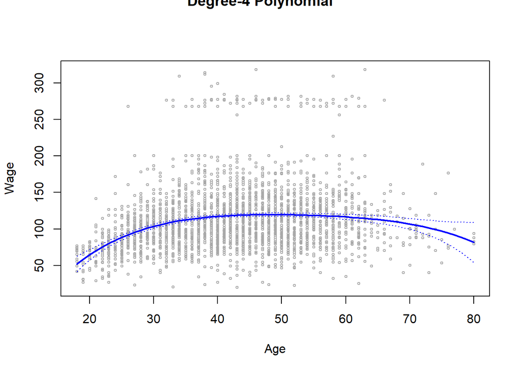

```r
#par(mfrow=c(1,2), mar=c(4.5,4.5,1,1), oma=c(0,0,4,0))
plot(Wage$age, Wage$wage, xlim=agelims, cex=.5, col="darkgrey",
     xlab = "Age", ylab = "Wage")
title("Degree-4 Polynomial", outer=T)
lines(age.grid, preds$fit, lwd=2, col="blue")
matlines(age.grid, se.bands, lwd=1, col="blue", lty=3)
```

Polinom derecesinin seçiminde klasik ANOVA yaklaşımı: polinom modeller birbirlerinin içinde yuvalanmış parametrelerde doğrusal modellerdir. Bu nedenle standart F testiyle modelleri sınayabiliriz. Bunun için `anova()` fonksiyonunu kullanabiliriz.

```r
fit.1 <- lm(wage ~ age, data=Wage)
fit.2 <- lm(wage ~ poly(age,2),data=Wage)
fit.3 <- lm(wage ~ poly(age,3),data=Wage)
fit.4 <- lm(wage ~ poly(age,4),data=Wage)
fit.5 <- lm(wage ~ poly(age,5),data=Wage)
anova(fit.1, fit.2, fit.3, fit.4, fit.5)
```

```
## Analysis of Variance Table
##
## Model 1: wage ~ age
## Model 2: wage ~ poly(age, 2)
## Model 3: wage ~ poly(age, 3)
## Model 4: wage ~ poly(age, 4)
## Model 5: wage ~ poly(age, 5)
##   Res.Df     RSS Df Sum of Sq        F    Pr(>F)
## 1   2998 5022216
## 2   2997 4793430  1    228786 143.5931 < 2.2e-16 ***
## 3   2996 4777674  1     15756   9.8888  0.001679 **
## 4   2995 4771604  1      6070   3.8098  0.051046 .
## 5   2994 4770322  1      1283   0.8050  0.369682
## ---
## Signif. codes:  0 '***' 0.001 '**' 0.01 '*' 0.05 '.' 0.1 ' ' 1
```

Model 1 (linear) vs. Model 2 (quadratic): p-değeri pratik olarak sıfır (< 2.2e-16). Model 1, Model 2 lehine reddedilir. Doğrusal model uygun değildir.

Model 2 vs. Model 3: p-value = 0.0017, Model 2 reddedilir.

Model 3 vs. Model 4: p değeri yaklaşık olarak %5; model 3, model 4 lehine reddedilir.

Model 4 vs. Model 5: p değeri = 0.37, Model 4 reddedilemez. Kübik ya da kuartik (dördüncü derece) polinom modeli uygun olabilir.

```r
coef(summary(fit.5))
```

```
##                 Estimate Std. Error     t value     Pr(>|t|)
## (Intercept)    111.70361  0.7287647 153.2780243 0.000000e+00
## poly(age, 5)1  447.06785 39.9160847  11.2001930 1.491111e-28
## poly(age, 5)2 -478.31581 39.9160847 -11.9830341 2.367734e-32
## poly(age, 5)3  125.52169 39.9160847   3.1446392 1.679213e-03
## poly(age, 5)4  -77.91118 39.9160847  -1.9518743 5.104623e-02
## poly(age, 5)5  -35.81289 39.9160847  -0.8972045 3.696820e-01
```

Polinom terimli lojistik regresyon modeli:

```r
fit <- glm( I(wage>250) ~ poly(age, 4), data=Wage, family=binomial)
preds <- predict(fit, newdata=list(age=age.grid), se=T)

# obtain standard error bands
pfit <- exp(preds$fit)/(1+exp(preds$fit))
se.bands.logit <- cbind(preds$fit+2*preds$se.fit, preds$fit-2*preds$se.fit)
se.bands <- exp(se.bands.logit)/(1+exp(se.bands.logit))
```

Şekil 7.1 (sağ panel):

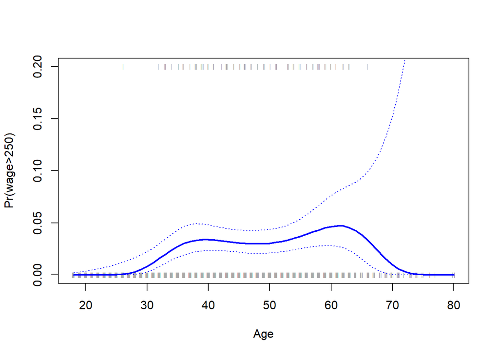

```r
plot(Wage$age, I(Wage$wage>250), xlim=agelims, type="n", ylim=c(0,.2),
     xlab = "Age", ylab = "Pr(wage>250)")
points(jitter(Wage$age), I((Wage$wage>250)/5),cex=.5,pch="|",col="darkgrey")
lines(age.grid,pfit,lwd=2, col="blue")
matlines(age.grid,se.bands,lwd=1,col="blue",lty=3)
```

Yukarıdaki kodda `jitter()` fonksiyonu `age` değerlerinin üst üste çakışmasını engeller. Böylece şekil daha kolay okunur.

Şekil 7.1’in her iki panelinin birlikte çizimi:

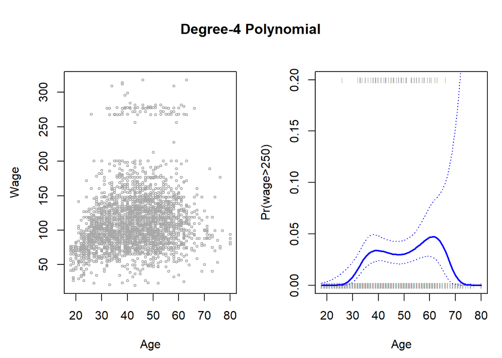

```r
par(mfrow=c(1,2), mar=c(4.5,4.5,1,1), oma=c(0,0,4,0))
plot(Wage$age, Wage$wage, xlim=agelims, cex=.5, col="darkgrey",
     xlab = "Age", ylab = "Wage")
title("Degree-4 Polynomial", outer=T)
lines(age.grid, preds$fit, lwd=2, col="blue")
matlines(age.grid, se.bands, lwd=1, col="blue", lty=3)

plot(Wage$age, I(Wage$wage>250), xlim=agelims, type="n", ylim=c(0,.2),
     xlab = "Age", ylab = "Pr(wage>250)")
points(jitter(Wage$age), I((Wage$wage>250)/5),cex=.5,pch="|",col="darkgrey")
lines(age.grid,pfit,lwd=2, col="blue")
matlines(age.grid,se.bands,lwd=1,col="blue",lty=3)
```

Adım fonksiyonunda kullanmak için `cut()` fonksiyonu ile sürekli bir değişkeni kategorik değişkene dönüştürebiliriz. Örneğin,

```r
table(cut(Wage$age, 4))
```

```
##
## (17.9,33.5]   (33.5,49]   (49,64.5] (64.5,80.1]
##         750        1399         779          72
```

OLS regresyonu içinde doğrudan kullanabiliriz:

```r
fit <- lm(wage ~ cut(age, 4), data = Wage)
coef(summary(fit))
```

```
##                         Estimate Std. Error   t value     Pr(>|t|)
## (Intercept)            94.158392   1.476069 63.789970 0.000000e+00
## cut(age, 4)(33.5,49]   24.053491   1.829431 13.148074 1.982315e-38
## cut(age, 4)(49,64.5]   23.664559   2.067958 11.443444 1.040750e-29
## cut(age, 4)(64.5,80.1]  7.640592   4.987424  1.531972 1.256350e-01
```

# 2 Spline Regresyonu

`R`’da `{splines}` kütüphanesini kullanarak spline regresyonu kurabiliriz. Baz fonksiyonlarının oluşturulmasında `bs()` fonksiyonu kullanılabilir (default = cubic). Örneğin,

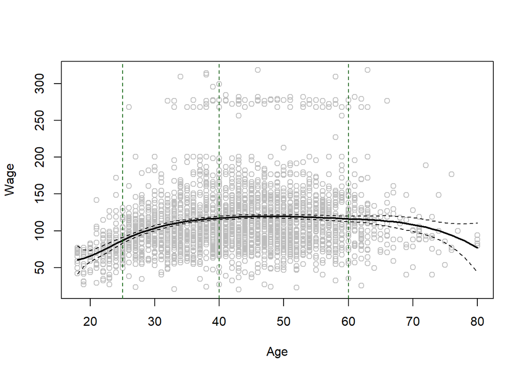

```r
library(splines)
fit <- lm(wage ~ bs(age, knots=c(25,40,60)), data=Wage)
pred <- predict(fit, newdata=list(age=age.grid), se=T)
plot(Wage$age, Wage$wage, col="gray",
     xlab = "Age", ylab = "Wage")
lines(age.grid, pred$fit, lwd=2)
lines(age.grid, pred$fit+2*pred$se, lty="dashed")
lines(age.grid, pred$fit-2*pred$se, lty="dashed")
abline(v=c(25,40,60), lty=2, col="darkgreen")
```

Düğüm noktaları: age = 25, 40, 60. Toplamda 6 baz fonksiyonu oluşturuldu. 3 düğüm noktalı bir kübik spline toplamda 7 serbestlik derecesine sahiptir (=3+3+1).

Alternatif olarak `df()` fonksiyonu ile uniform aralıklar kullanarak düğüm noktalarını belirleyebiliriz.

```r
dim(bs(Wage$age, knots=c(25,40,60)))
```

```
## [1] 3000    6
```

```r
dim(bs(Wage$age, df=6))
```

```
## [1] 3000    6
```

```r
attr(bs(Wage$age, df=6), "knots")
```

```
##   25%   50%   75%
## 33.75 42.00 51.00
```

Burada `R` düğüm noktalarını 33.8, 42.0, ve 51.0 değerlerinde oluşturdu. Bu değerler, sırasıyla, 25, 50 ve 75nci yüzdelik dilimlerdir (1,2,3. kartiller).

## 2.1 Doğal Spline’lar

Bu amaçla `splines::ns()` fonksiyonu kullanılabilir. Örneğin

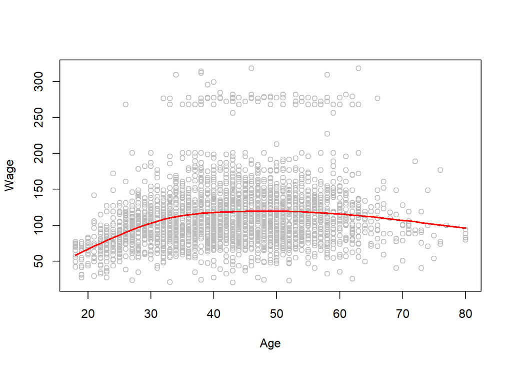

```r
fit2 <- lm(wage ~ ns(age, df=4), data=Wage)
pred2 <- predict(fit2, newdata=list(age=age.grid), se=T)
plot(Wage$age, Wage$wage, col="grey",
     xlab = "Age", ylab = "Wage")
lines(age.grid, pred2$fit, col="red",lwd=2)
```

## 2.2 Smoothing Splines

Bunun için `stats::smooth.spline()` fonksiyonu kullanılabilir:

```r
plot(Wage$age, Wage$wage, xlim = agelims, cex = 0.5, col="darkgrey",
     xlab = "Age", ylab = "Wage")
title(" Smoothing Spline ")
# fit a smoothing spline with degree 16
fit <- smooth.spline(Wage$age, Wage$wage, df = 16)
# chose df using cross-validation
fit2 <- smooth.spline(Wage$age, Wage$wage, cv = TRUE)
# cv yields df=6.8
fit2$df
```

```
## [1] 6.794596
```

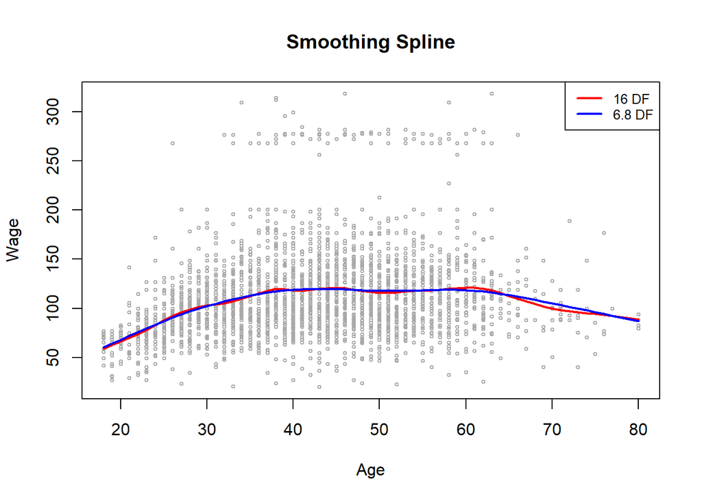

```r
lines(fit, col="red",lwd=2)
lines(fit2, col="blue",lwd=2)
legend("topright",legend=c("16 DF","6.8 DF"),col=c("red","blue"),lty=1,lwd=2,cex=.8)
```

## 2.3 Örnek: simülasyon verileriyle spline regresyonu

Önce veri setimizi oluşturalım:

```r
# simulate data
set.seed(12345)
n  <- 100
x  <- seq(0,1,length=n)
fx <- 5*x*sin(2*pi*x) + 4*cos(3*pi*x)
y  <- rnorm(n,fx,1)
data = data.frame(y,x)
```

Verilerin grafiği:

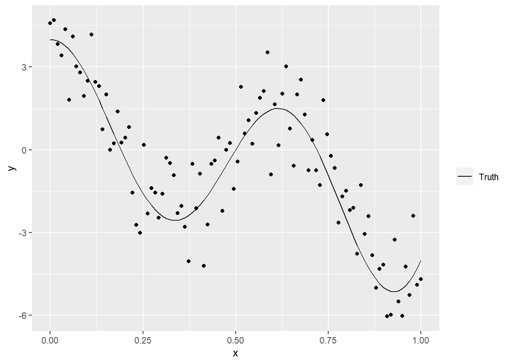

```r
library(ggplot2)
p1 <- ggplot(data,aes(x,y)) +
       geom_point()

p1 + geom_line(aes(x,fx,col="Truth")) +
  scale_colour_manual(" ", values=c("Truth"="black"))
```

İki düğüm noktası tanımlayalım:

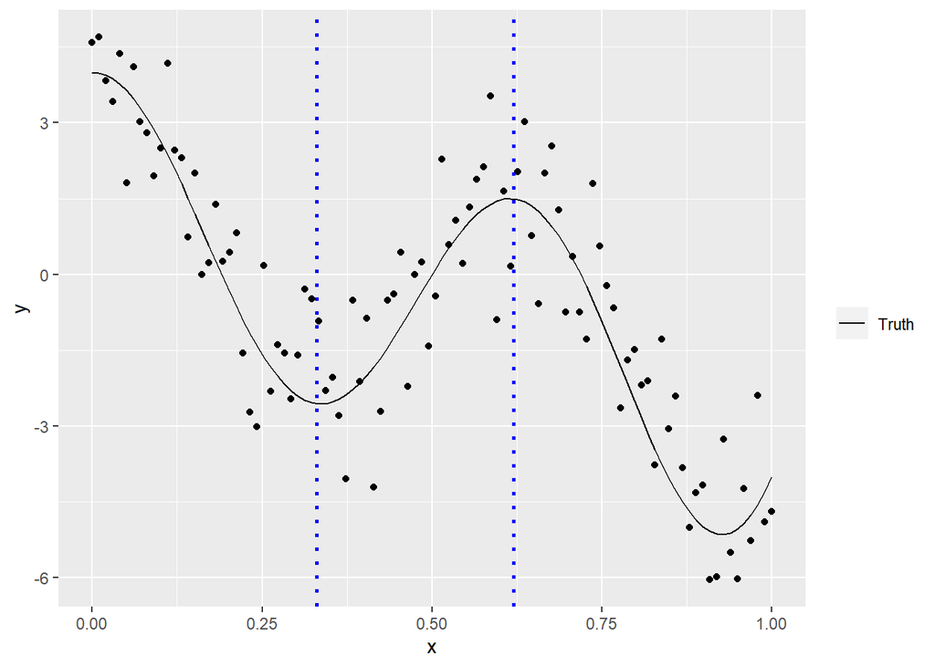

```r
# we have  knots
k1 <- 0.33
k2 <- 0.62
p1 + geom_line(aes(x,fx,col="Truth")) +
     scale_colour_manual(" ", values=c("Truth"="black")) +
     geom_vline(xintercept=c(k1,k2),
                linetype="dotted", color = "blue", size=1)
```

```r
data$k1dummy <- ifelse(data$x>k1,1,0)
data$k1diff <- data$x - k1
data$xk1 <- data$k1diff*data$k1dummy
#
data$k2dummy <- ifelse(data$x>k2,1,0)
data$k2diff <- data$x - k2
data$xk2 <- data$k2diff*data$k2dummy
```

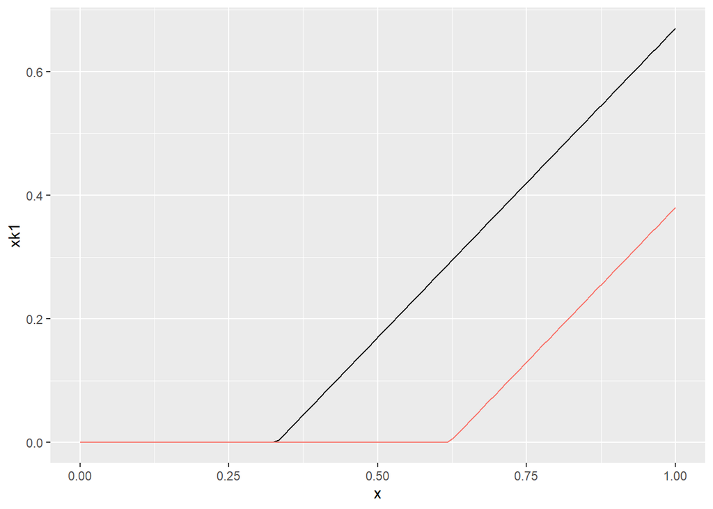

```r
ggplot(data, aes(x,xk1)) +
  geom_line() +
  geom_line(aes(x,xk2,col="red")) +
  theme(legend.position = "none")
```

`bs()` fonksiyonu ile görselleştirme:

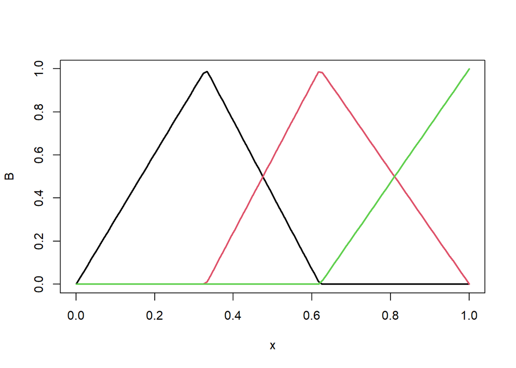

```r
library(splines)
B = bs(x,knots=c(k1,k2),degre=1)
matplot(x,B,type="l",lty=1,lwd=2)
```

İkinci derece spline:

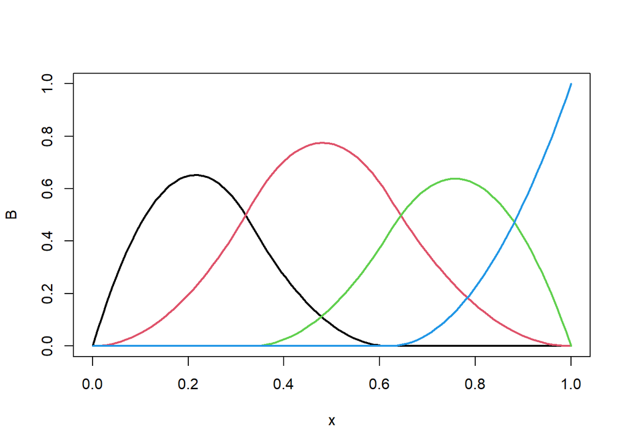

```r
B = bs(x,knots=c(k1,k2),degre=2)
matplot(x,B,type="l",lty=1,lwd=2)
```

Kübik spline:

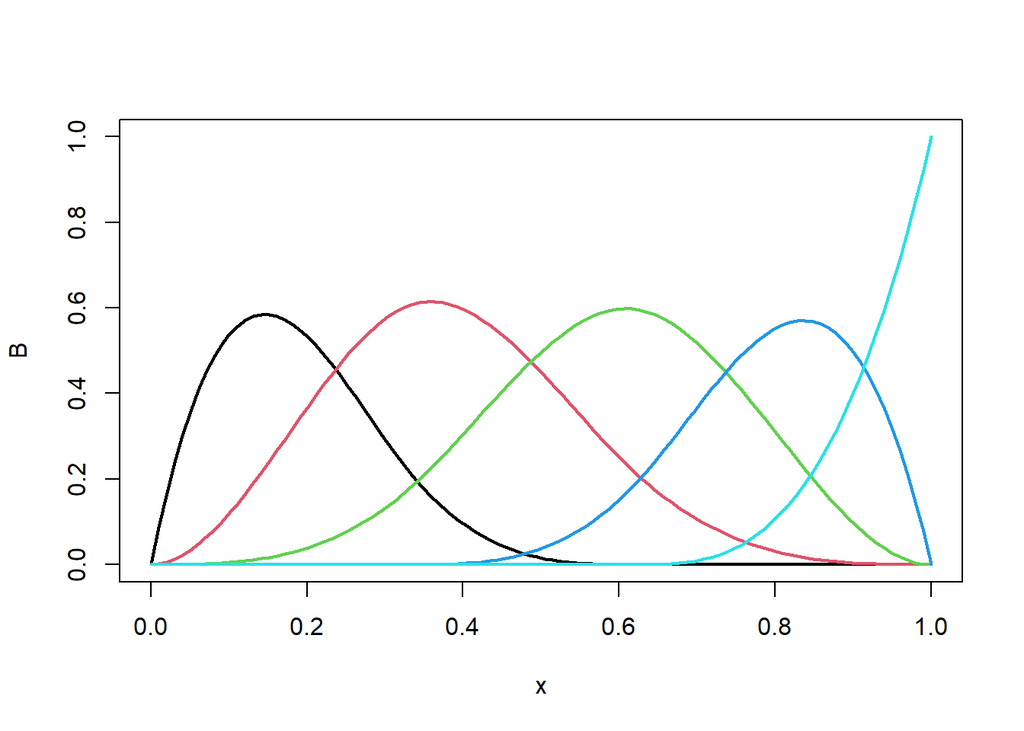

```r
B = bs(x,knots=c(k1,k2),degre=3)
matplot(x,B,type="l",lty=1,lwd=2)
```

Spline regresyonları OLS ile kolayca tahmin edilebilir:

```r
# least squares estimation
model1  <- lm(y ~ x + xk1 +xk2, data=data)
summary(model1)
```

```
##
## Call:
## lm(formula = y ~ x + xk1 + xk2, data = data)
##
## Residuals:
##     Min      1Q  Median      3Q     Max
## -2.8855 -0.6839  0.1047  0.7506  3.0441
##
## Coefficients:
##             Estimate Std. Error t value Pr(>|t|)
## (Intercept)   4.5385     0.3803   11.93   <2e-16 ***
## x           -21.7928     1.6927  -12.88   <2e-16 ***
## xk1          37.5643     2.9413   12.77   <2e-16 ***
## xk2         -36.2132     2.6795  -13.52   <2e-16 ***
## ---
## Signif. codes:  0 '***' 0.001 '**' 0.01 '*' 0.05 '.' 0.1 ' ' 1
##
## Residual standard error: 1.194 on 96 degrees of freedom
## Multiple R-squared:  0.8025, Adjusted R-squared:  0.7963
## F-statistic:   130 on 3 and 96 DF,  p-value: < 2.2e-16
```

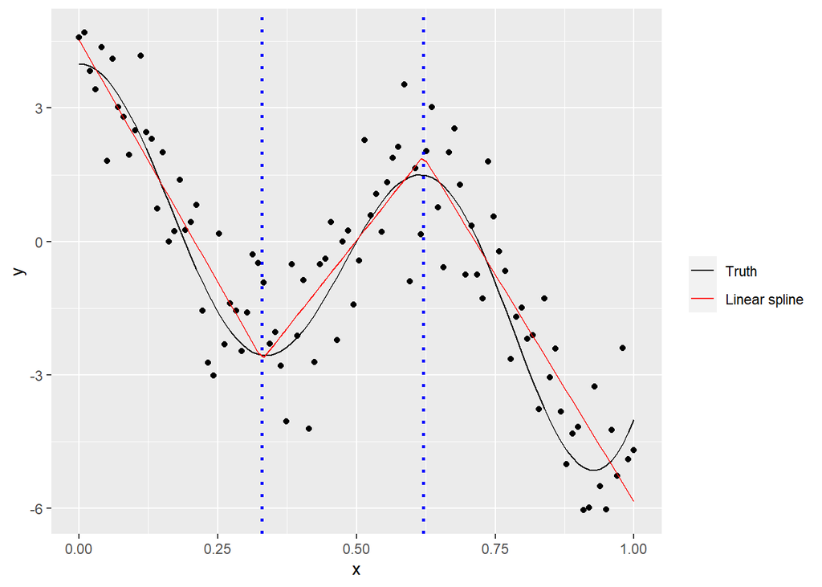

```r
yhat <- model1$fitted.values

p1 + geom_line(aes(x,fx,col="Truth")) +
  geom_line(aes(x,yhat,col="Linear spline")) +
  scale_colour_manual(" ", values=c("Truth"="black","Linear spline"="red")) +
  geom_vline(xintercept=c(k1,k2),
                linetype="dotted", color = "blue", size=1)
```

**Soru** `k1` noktasında sadece bir düğüm noktası ve doğrusal spline kullansaydık nasıl bir tahmin elde ederdik?

**Cevap**

```r
# least squares estimation
model1.a  <- lm(y ~ x + xk1, data=data)
summary(model1.a)
```

```
##
## Call:
## lm(formula = y ~ x + xk1, data = data)
##
## Residuals:
##    Min     1Q Median     3Q    Max
## -3.650 -1.578  0.045  1.265  4.830
##
## Coefficients:
##             Estimate Std. Error t value Pr(>|t|)
## (Intercept)   3.4476     0.6299   5.473 3.46e-07 ***
## x           -11.5667     2.5663  -4.507 1.84e-05 ***
## xk1           7.9507     3.3256   2.391   0.0187 *
## ---
## Signif. codes:  0 '***' 0.001 '**' 0.01 '*' 0.05 '.' 0.1 ' ' 1
##
## Residual standard error: 2.024 on 97 degrees of freedom
## Multiple R-squared:  0.4268, Adjusted R-squared:  0.4149
## F-statistic: 36.11 on 2 and 97 DF,  p-value: 1.902e-12
```

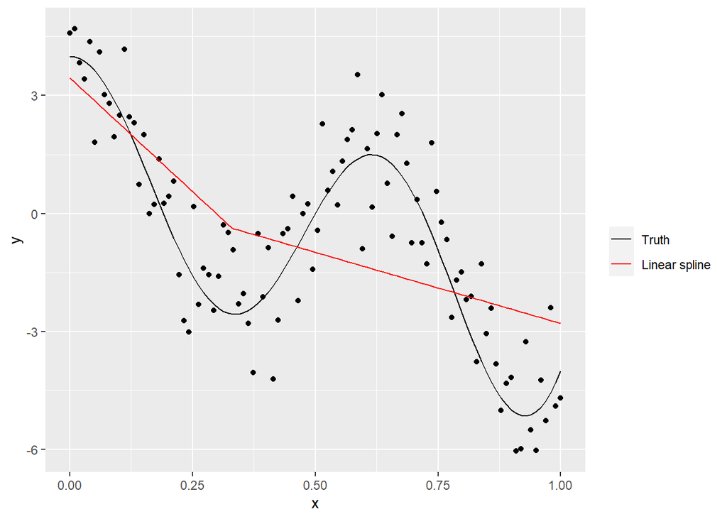

```r
yhat.a <- model1.a$fitted.values

p1 + geom_line(aes(x,fx,col="Truth")) +
  geom_line(aes(x,yhat.a,col="Linear spline")) +
  scale_colour_manual(" ", values=c("Truth"="black","Linear spline"="red"))
```

`{splines}` paketi ile:

```r
library(splines)
model1.bs <- lm(y ~ bs(x, knots = c(k1,k2), degree=1), data=data)
summary(model1.bs)
```

```
##
## Call:
## lm(formula = y ~ bs(x, knots = c(k1, k2), degree = 1), data = data)
##
## Residuals:
##     Min      1Q  Median      3Q     Max
## -2.8855 -0.6839  0.1047  0.7506  3.0441
##
## Coefficients:
##                                       Estimate Std. Error t value Pr(>|t|)
## (Intercept)                             4.5385     0.3803  11.933  < 2e-16 ***
## bs(x, knots = c(k1, k2), degree = 1)1  -7.1916     0.5586 -12.875  < 2e-16 ***
## bs(x, knots = c(k1, k2), degree = 1)2  -2.6179     0.4519  -5.793 8.73e-08 ***
## bs(x, knots = c(k1, k2), degree = 1)3 -10.3858     0.5313 -19.548  < 2e-16 ***
## ---
## Signif. codes:  0 '***' 0.001 '**' 0.01 '*' 0.05 '.' 0.1 ' ' 1
##
## Residual standard error: 1.194 on 96 degrees of freedom
## Multiple R-squared:  0.8025, Adjusted R-squared:  0.7963
## F-statistic:   130 on 3 and 96 DF,  p-value: < 2.2e-16
```

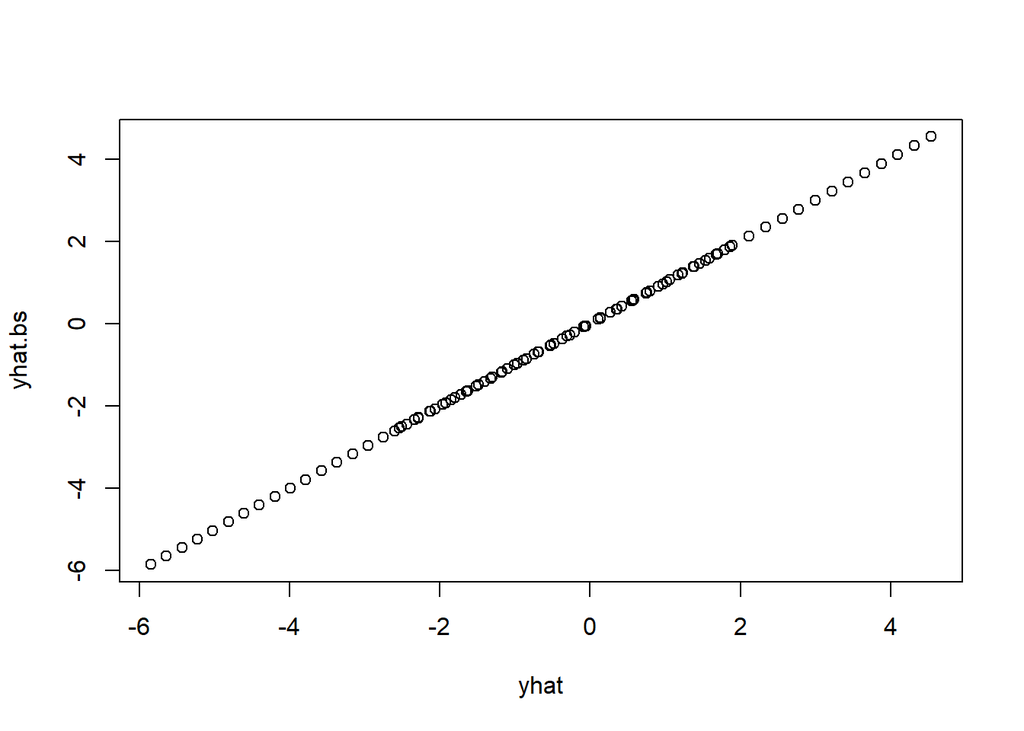

```r
yhat.bs <- model1.bs$fitted.values
# compare predictions
plot(yhat, yhat.bs)
```

```r
sum(yhat-yhat.bs)
```

```
## [1] 2.858824e-15
```

İkinci derece spline:

```r
# quadratic fit
model2.bs <- lm(y ~ bs(x, knots = c(k1,k2), degree=2), data=data)
summary(model2.bs)
```

```
##
## Call:
## lm(formula = y ~ bs(x, knots = c(k1, k2), degree = 2), data = data)
##
## Residuals:
##     Min      1Q  Median      3Q     Max
## -3.6924 -1.0746 -0.0456  0.9951  3.5613
##
## Coefficients:
##                                       Estimate Std. Error t value Pr(>|t|)
## (Intercept)                             5.8581     0.6292   9.310 4.93e-15 ***
## bs(x, knots = c(k1, k2), degree = 2)1  -8.1851     1.0806  -7.575 2.34e-11 ***
## bs(x, knots = c(k1, k2), degree = 2)2  -5.8493     0.6956  -8.409 4.10e-13 ***
## bs(x, knots = c(k1, k2), degree = 2)3  -5.2319     0.9367  -5.586 2.21e-07 ***
## bs(x, knots = c(k1, k2), degree = 2)4 -12.5679     0.8427 -14.915  < 2e-16 ***
## ---
## Signif. codes:  0 '***' 0.001 '**' 0.01 '*' 0.05 '.' 0.1 ' ' 1
##
## Residual standard error: 1.451 on 95 degrees of freedom
## Multiple R-squared:  0.7116, Adjusted R-squared:  0.6994
## F-statistic:  58.6 on 4 and 95 DF,  p-value: < 2.2e-16
```

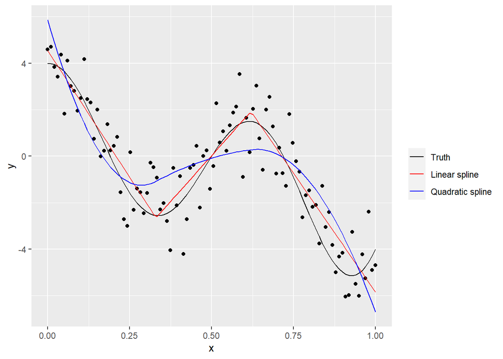

```r
yhat2.bs <- model2.bs$fitted.values

p1 + geom_line(aes(x,fx,col="Truth")) +
     geom_line(aes(x,yhat.bs,col="Linear spline")) +
     geom_line(aes(x,yhat2.bs,col="Quadratic spline")) +
     scale_colour_manual(" ", values=c("Truth"="black",
                                       "Linear spline"="red",
                                       "Quadratic spline"="blue")) +
     theme(legend.position = "right")
```

Kübik spline:

```r
# Cubic spline fit
model3.bs <- lm(y ~ bs(x, knots = c(k1,k2), degree=3), data=data)
summary(model3.bs)
```

```
##
## Call:
## lm(formula = y ~ bs(x, knots = c(k1, k2), degree = 3), data = data)
##
## Residuals:
##     Min      1Q  Median      3Q     Max
## -2.7179 -0.7895  0.1075  0.6046  2.3590
##
## Coefficients:
##                                       Estimate Std. Error t value Pr(>|t|)
## (Intercept)                             4.1560     0.5980   6.950 4.75e-10 ***
## bs(x, knots = c(k1, k2), degree = 3)1  -0.3666     1.1643  -0.315  0.75353
## bs(x, knots = c(k1, k2), degree = 3)2 -11.2863     0.7670 -14.716  < 2e-16 ***
## bs(x, knots = c(k1, k2), degree = 3)3   3.0505     1.0501   2.905  0.00458 **
## bs(x, knots = c(k1, k2), degree = 3)4 -10.5098     0.8795 -11.950  < 2e-16 ***
## bs(x, knots = c(k1, k2), degree = 3)5  -8.6936     0.8509 -10.217  < 2e-16 ***
## ---
## Signif. codes:  0 '***' 0.001 '**' 0.01 '*' 0.05 '.' 0.1 ' ' 1
##
## Residual standard error: 1.126 on 94 degrees of freedom
## Multiple R-squared:  0.8281, Adjusted R-squared:  0.819
## F-statistic: 90.57 on 5 and 94 DF,  p-value: < 2.2e-16
```

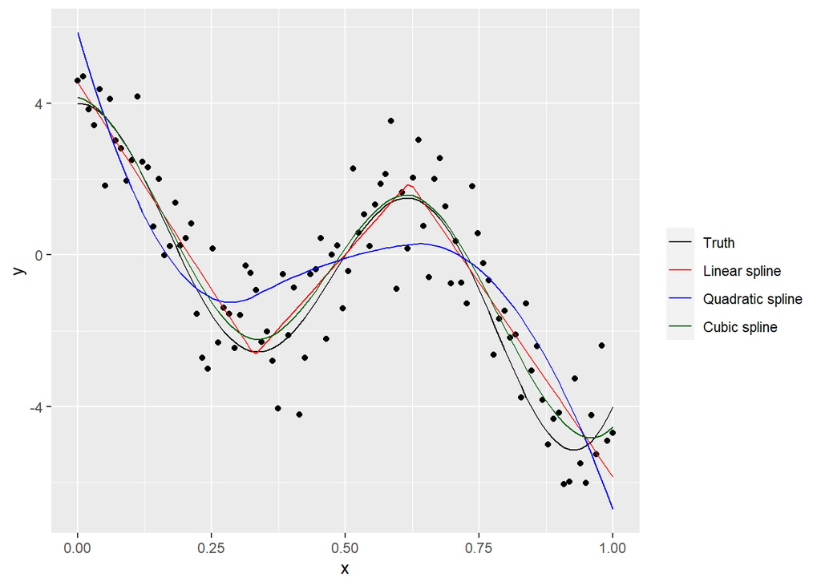

```r
yhat3.bs <- model3.bs$fitted.values

p1 + geom_line(aes(x,fx,col="Truth")) +
     geom_line(aes(x,yhat.bs,col="Linear spline")) +
     geom_line(aes(x,yhat2.bs,col="Quadratic spline")) +
     geom_line(aes(x,yhat3.bs,col="Cubic spline")) +
     scale_colour_manual(" ", values=c("Truth"="black",
                                       "Linear spline"="red",
                                       "Quadratic spline"="blue",
                                       "Cubic spline"="darkgreen")) +
  theme(legend.position = "right")
```

Alternatif: serbestlik derecesini (df) belirle, düğüm noktaları otomatik olarak oluşturulacak:

```r
modeldf10  <- lm(y ~ bs(x, 10), data=data)
yhatdf10.bs <- modeldf10$fitted.values
summary(modeldf10)
```

```
##
## Call:
## lm(formula = y ~ bs(x, 10), data = data)
##
## Residuals:
##     Min      1Q  Median      3Q     Max
## -2.6700 -0.7664  0.0501  0.7061  2.2627
##
## Coefficients:
##             Estimate Std. Error t value Pr(>|t|)
## (Intercept)   4.5761     0.8645   5.294 8.56e-07 ***
## bs(x, 10)1   -1.2005     1.6567  -0.725 0.470589
## bs(x, 10)2   -2.0115     1.1429  -1.760 0.081828 .
## bs(x, 10)3   -6.4113     1.2708  -5.045 2.38e-06 ***
## bs(x, 10)4   -7.1879     1.0948  -6.566 3.36e-09 ***
## bs(x, 10)5   -4.3783     1.1626  -3.766 0.000297 ***
## bs(x, 10)6   -2.1992     1.1299  -1.946 0.054780 .
## bs(x, 10)7   -4.8896     1.1910  -4.105 8.94e-05 ***
## bs(x, 10)8   -8.6678     1.3303  -6.516 4.21e-09 ***
## bs(x, 10)9  -10.4482     1.3673  -7.642 2.35e-11 ***
## bs(x, 10)10  -8.4925     1.2214  -6.953 5.75e-10 ***
## ---
## Signif. codes:  0 '***' 0.001 '**' 0.01 '*' 0.05 '.' 0.1 ' ' 1
##
## Residual standard error: 1.144 on 89 degrees of freedom
## Multiple R-squared:  0.832,  Adjusted R-squared:  0.8131
## F-statistic: 44.08 on 10 and 89 DF,  p-value: < 2.2e-16
```

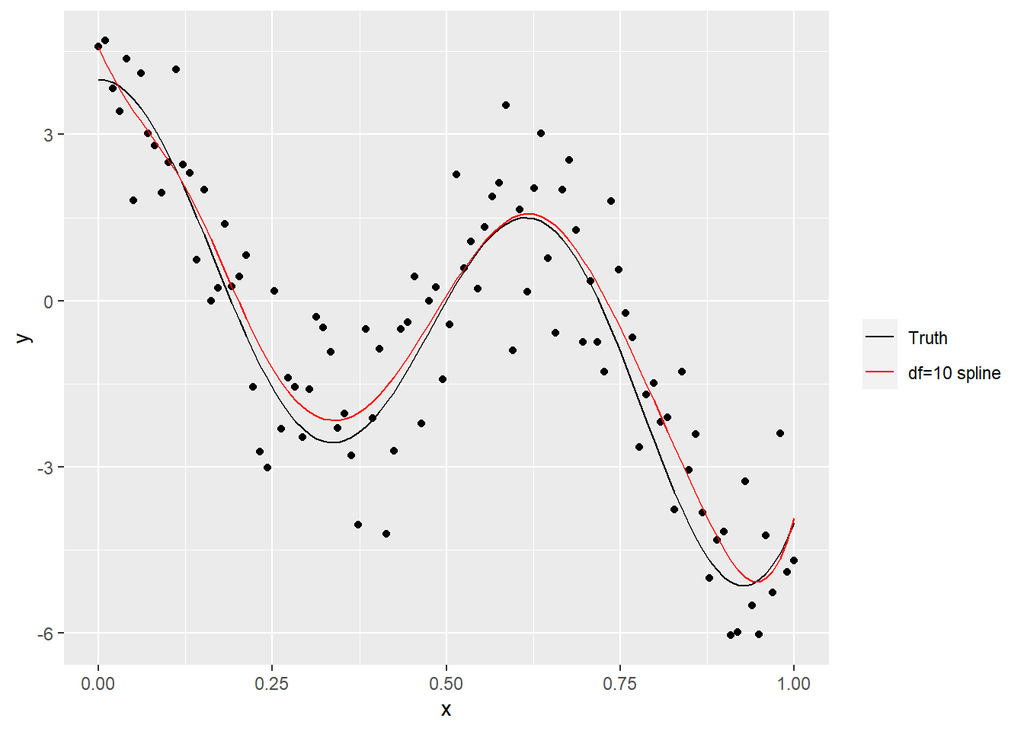

```r
p1 + geom_line(aes(x,fx,col="Truth")) +
  geom_line(aes(x,yhatdf10.bs,col="df=10 spline")) +
  scale_colour_manual(" ", values=c("Truth"="black","df=10 spline"="red"))
```

Smoothing spline df=10:

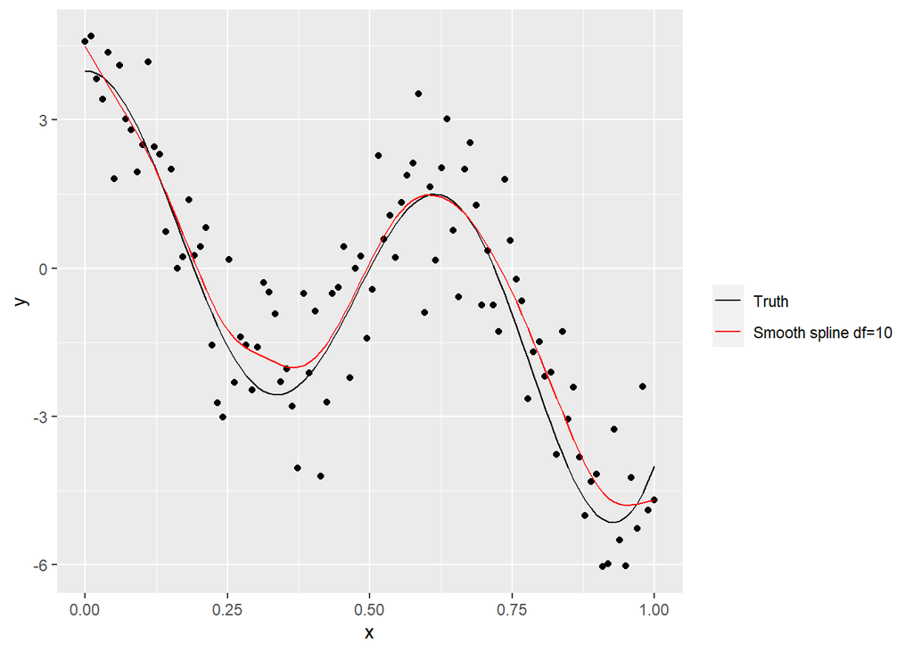

```r
ssfit <- smooth.spline(x, y, df = 10)
p1 + geom_line(aes(x,fx,col="Truth")) +
     geom_line(aes(x,ssfit$y,col="Smooth spline df=10")) +
  scale_colour_manual(" ", values=c("Truth"="black","Smooth spline df=10"="red"))
```

Çapraz geçerleme ile df’in seçimi:

```r
ssfitcv <- smooth.spline(x, y, cv=TRUE)
ssfitcv$df
```

```
## [1] 8.847658
```

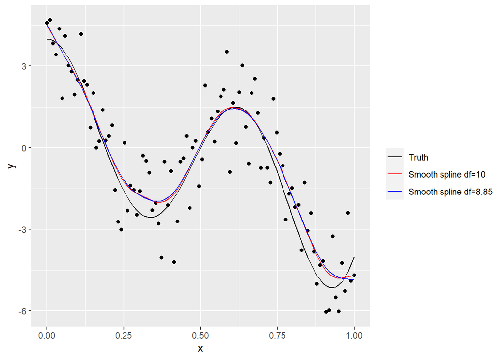

```r
p1 + geom_line(aes(x,fx,col="Truth")) +
  geom_line(aes(x,ssfit$y,col="Smooth spline df=10")) +
  geom_line(aes(x,ssfitcv$y,col="Smooth spline df=8.85")) +
  scale_colour_manual(" ", values=c("Truth"="black",
                                    "Smooth spline df=10"="red",
                                    "Smooth spline df=8.85"="blue"))
```

# 3 Yerel Regresyon

Bu amaçla `stats::loess()` fonksiyonu kullanılabilir. Detaylar için bkz. `?loess`. (loess: locally estimated scatterplot smoothing ya da LOcal regrESSion, aka lowess: locally weighted scatterplot smoothing).

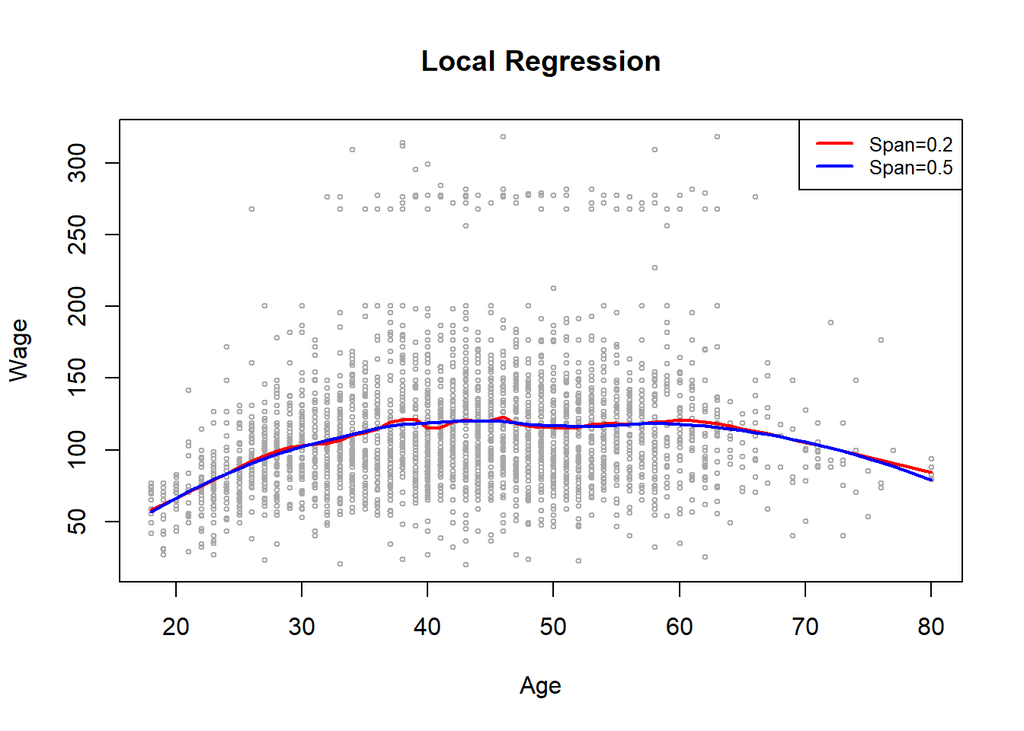

```r
plot(Wage$age, Wage$wage, xlim = agelims, cex = 0.5, col="darkgrey",
     xlab = "Age", ylab = "Wage")
title("Local Regression")
fit <- loess(wage ~ age, span=0.2, data=Wage)
fit2 <- loess(wage ~ age, span=0.5, data=Wage)
lines(age.grid, predict(fit, data.frame(age=age.grid)), col="red", lwd=2)
lines(age.grid, predict(fit2, data.frame(age=age.grid)), col="blue", lwd=2)
legend("topright", legend=c("Span=0.2","Span=0.5"),
       col=c("red","blue"), lty=1, lwd=2, cex=.8)
```

Yerel regresyonda tahminde kullanılan yerel verileri `span` değeri belirler. Yukarıda iki değer kullanılmıştır: 0.2 ve 0.5, sırasıyla verilerin %20’si ve %50’si dahil edilmiştir. Span değeri büyüdükçe tahmin edilen eğri düzleşir. Yerel regresyonun tahmininde alternatif olarak `{locfit}` kütüphanesi de kullanılabilir.

**Örnek**: Simülasyon verileri ile yerel regresyon:

```r
library(tidyverse)
data_fit <- loess(y ~ x, span = 0.1, data = data)
y_hat <- predict(data_fit, data$x)
data_fit2 <- loess(y ~ x, span = 0.3, data = data)
y_hat2 <- predict(data_fit2, data$x)
df <- tibble(y = data$y,
             x = data$x,
             pred = y_hat,
             pred2 = y_hat2)
head(df)
```

```
## # A tibble: 6 x 4
##       y      x  pred pred2
##   <dbl>  <dbl> <dbl> <dbl>
## 1  4.59 0       4.75  4.31
## 2  4.69 0.0101  4.34  4.18
## 3  3.83 0.0202  3.97  4.03
## 4  3.41 0.0303  3.66  3.88
## 5  4.37 0.0404  3.46  3.72
## 6  1.82 0.0505  3.31  3.56
```

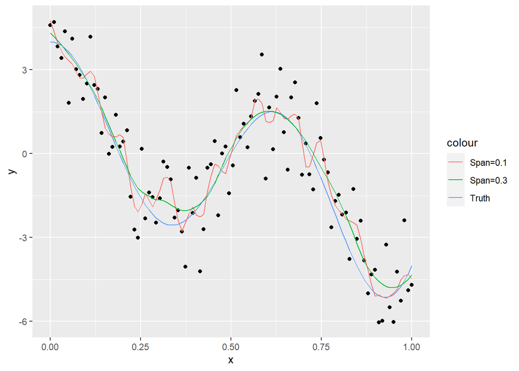

```r
ggplot(df, aes(x,y)) + geom_point() +
  geom_line(aes(x,fx,col="Truth")) +
  geom_line(aes(x,pred, col="Span=0.1")) +
  geom_line(aes(x,pred2, col="Span=0.3"))
```

`ggplot2::geom_smooth()` ile LOESS:

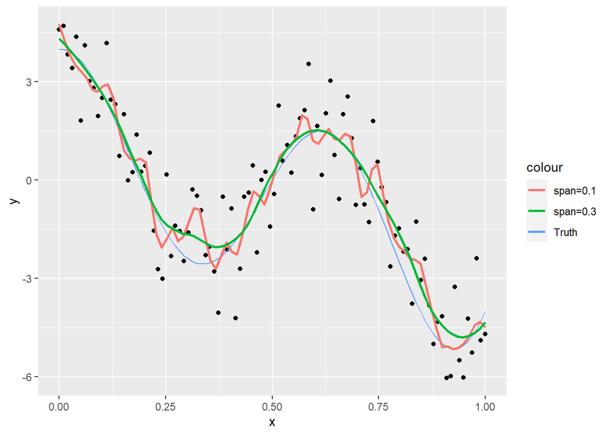

```r
ggplot(data, aes(x,y)) +
  geom_point() +
  geom_line(aes(x,fx,col="Truth")) +
  geom_smooth(method = "loess", span=0.1, se = FALSE, aes(col="span=0.1")) +
  geom_smooth(method = "loess", span=0.3, se = FALSE, aes(col="span=0.3"))
```

# 4 Generalized Additive Models (GAMs)

Bir GAM modeli `lm()` fonksiyonu yardımıyla tahmin edilebilir. Örneğin

```r
gam1 <- lm(wage ~ ns(year,4) + ns(age,5) + education, data=Wage)
summary(gam1)
```

```
##
## Call:
## lm(formula = wage ~ ns(year, 4) + ns(age, 5) + education, data = Wage)
##
## Residuals:
##      Min       1Q   Median       3Q      Max
## -120.513  -19.608   -3.583   14.112  214.535
##
## Coefficients:
##                             Estimate Std. Error t value Pr(>|t|)
## (Intercept)                   46.949      4.704   9.980  < 2e-16 ***
## ns(year, 4)1                   8.625      3.466   2.488  0.01289 *
## ns(year, 4)2                   3.762      2.959   1.271  0.20369
## ns(year, 4)3                   8.127      4.211   1.930  0.05375 .
## ns(year, 4)4                   6.806      2.397   2.840  0.00455 **
## ns(age, 5)1                   45.170      4.193  10.771  < 2e-16 ***
## ns(age, 5)2                   38.450      5.076   7.575 4.78e-14 ***
## ns(age, 5)3                   34.239      4.383   7.813 7.69e-15 ***
## ns(age, 5)4                   48.678     10.572   4.605 4.31e-06 ***
## ns(age, 5)5                    6.557      8.367   0.784  0.43328
## education2. HS Grad           10.983      2.430   4.520 6.43e-06 ***
## education3. Some College      23.473      2.562   9.163  < 2e-16 ***
## education4. College Grad      38.314      2.547  15.042  < 2e-16 ***
## education5. Advanced Degree   62.554      2.761  22.654  < 2e-16 ***
## ---
## Signif. codes:  0 '***' 0.001 '**' 0.01 '*' 0.05 '.' 0.1 ' ' 1
##
## Residual standard error: 35.16 on 2986 degrees of freedom
## Multiple R-squared:  0.293,  Adjusted R-squared:  0.2899
## F-statistic:  95.2 on 13 and 2986 DF,  p-value: < 2.2e-16
```

Ancak smoothing splines için `lm()` fonksiyonu kullanılamaz. Bunun için `gam` kütüphanesini yükleyip kullanabiliriz:

```r
library(gam)
gam.m3 <- gam(wage ~ s(year,4) + s(age,5) + education, data=Wage)
```

`gam::s()`: smoothing spline. Yukarıdaki koda göre year için df = 4, age için df=5 olarak belirlenmiştir. Education nitel bir değişken olduğundan bir dönüştürme yapılmadan kullanılmıştır (kukla değişken).

Tahmin edilen fonksiyonların görselleştirilmesi:

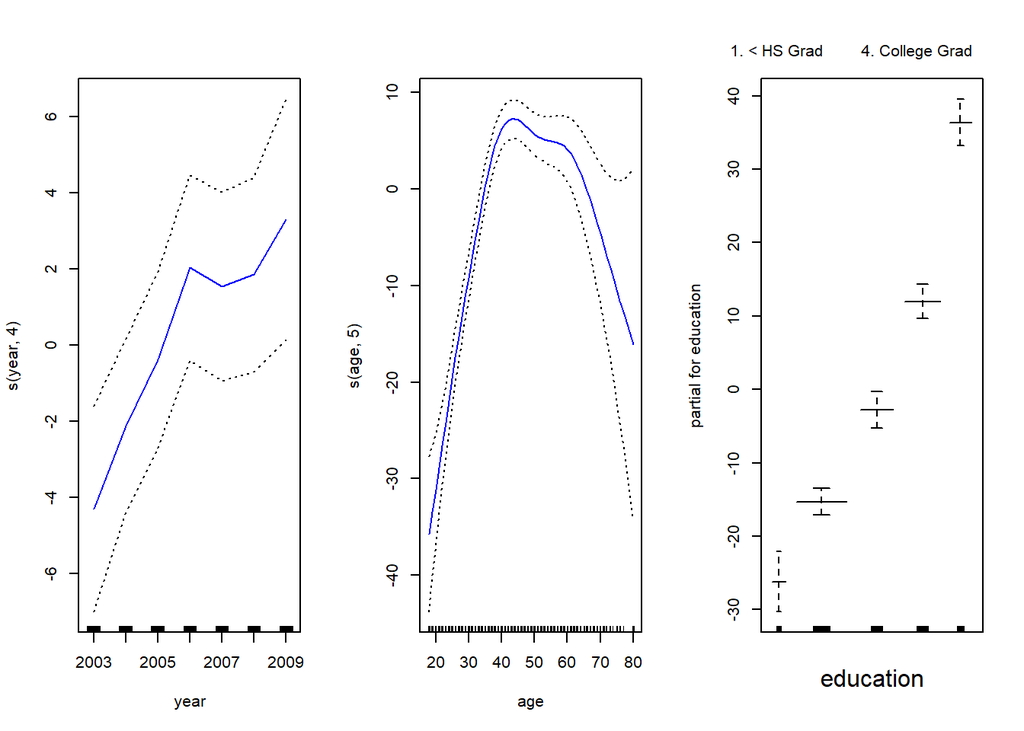

```r
par(mfrow=c(1,3))
plot(gam.m3, se=TRUE,col="blue")
```

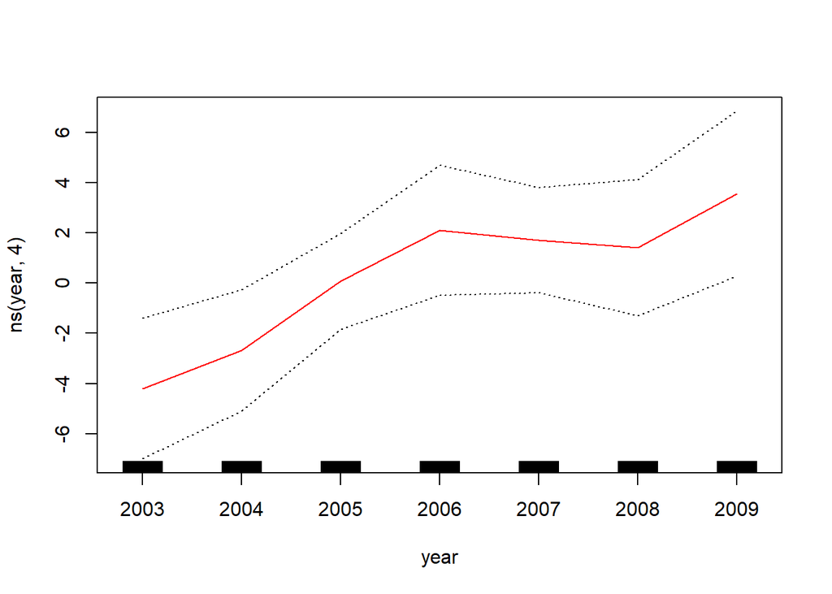

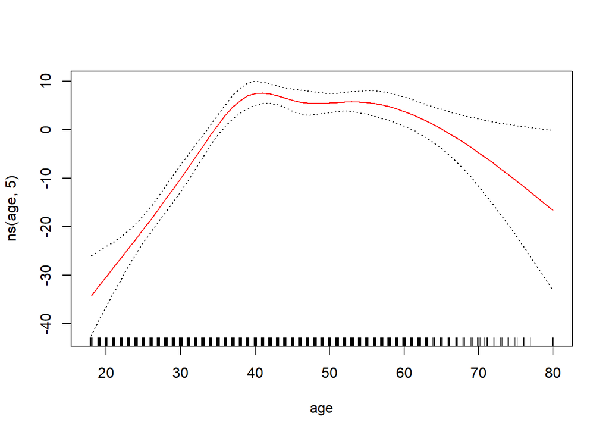

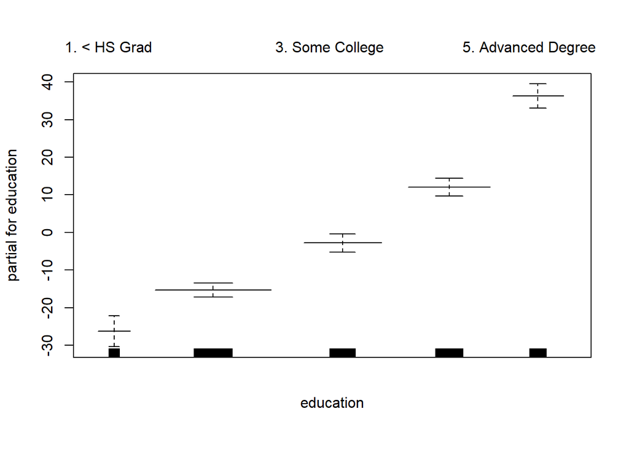

```r
plot.Gam(gam1 , se=TRUE , col ="red ")
```

Tahmin sonrası `anova()` testleri:

m1: GAM excludes year m2: GAM uses a linear function of year m3: GAM uses a spline function of year (estimated previously)

```r
gam.m1 <- gam(wage ~ s(age,5) + education, data=Wage)
gam.m2 <- gam(wage ~ year + s(age,5) + education, data=Wage)
anova(gam.m1, gam.m2, gam.m3, test="F")
```

```
## Analysis of Deviance Table
##
## Model 1: wage ~ s(age, 5) + education
## Model 2: wage ~ year + s(age, 5) + education
## Model 3: wage ~ s(year, 4) + s(age, 5) + education
##   Resid. Df Resid. Dev Df Deviance       F    Pr(>F)
## 1      2990    3711731
## 2      2989    3693842  1  17889.2 14.4771 0.0001447 ***
## 3      2986    3689770  3   4071.1  1.0982 0.3485661
## ---
## Signif. codes:  0 '***' 0.001 '**' 0.01 '*' 0.05 '.' 0.1 ' ' 1
```

Sonuçlara göre m2 m1’e tercih edilir, yani year değişkeninin olduğu model daha iyidir. Ancak m2 vs m3 karşılaştırmasında m2 tercih edilir. Doğrusal olmayan dönüştürmeye gerek yoktur.

Tahmin edilen modelin özeti: `summary()` fonksiyonu

```r
summary(gam.m3)
```

```
##
## Call: gam(formula = wage ~ s(year, 4) + s(age, 5) + education, data = Wage)
## Deviance Residuals:
##     Min      1Q  Median      3Q     Max
## -119.43  -19.70   -3.33   14.17  213.48
##
## (Dispersion Parameter for gaussian family taken to be 1235.69)
##
##     Null Deviance: 5222086 on 2999 degrees of freedom
## Residual Deviance: 3689770 on 2986 degrees of freedom
## AIC: 29887.75
##
## Number of Local Scoring Iterations: NA
##
## Anova for Parametric Effects
##              Df  Sum Sq Mean Sq F value    Pr(>F)
## s(year, 4)    1   27162   27162  21.981 2.877e-06 ***
## s(age, 5)     1  195338  195338 158.081 < 2.2e-16 ***
## education     4 1069726  267432 216.423 < 2.2e-16 ***
## Residuals  2986 3689770    1236
## ---
## Signif. codes:  0 '***' 0.001 '**' 0.01 '*' 0.05 '.' 0.1 ' ' 1
##
## Anova for Nonparametric Effects
##             Npar Df Npar F  Pr(F)
## (Intercept)
## s(year, 4)        3  1.086 0.3537
## s(age, 5)         4 32.380 <2e-16 ***
## education
## ---
## Signif. codes:  0 '***' 0.001 '**' 0.01 '*' 0.05 '.' 0.1 ' ' 1
```

`Anova for Nonparametric Effects` başlığı altındaki F testleri ve p-değerleri doğrusal ve doğrusal olmayan modelleri karşılaştırır. Year değişkeni için doğrusal model tercih edilir çünkü p-değeri (0.35) büyüktür. Age için ise boş hipotez reddedilir ve doğrusal olmayan model tercih edilir.

Kestirimlerin oluşturulması:

```r
preds <- predict(gam.m2, newdata=Wage)
```

GAM içinde `lo()` fonksiyonu ile LOESS düzleştirmesi de yapılabilir:

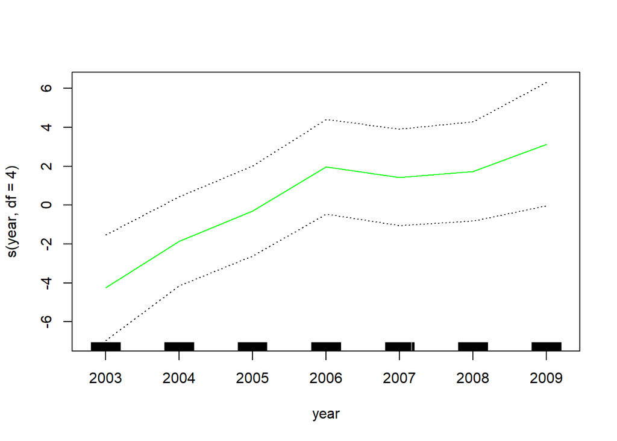

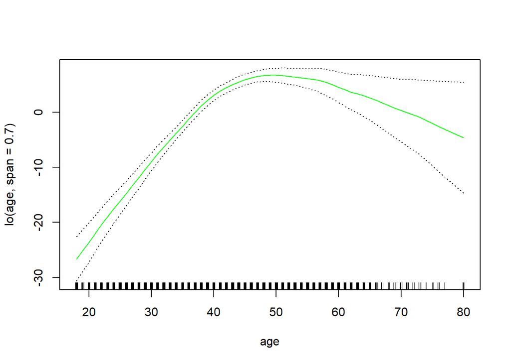

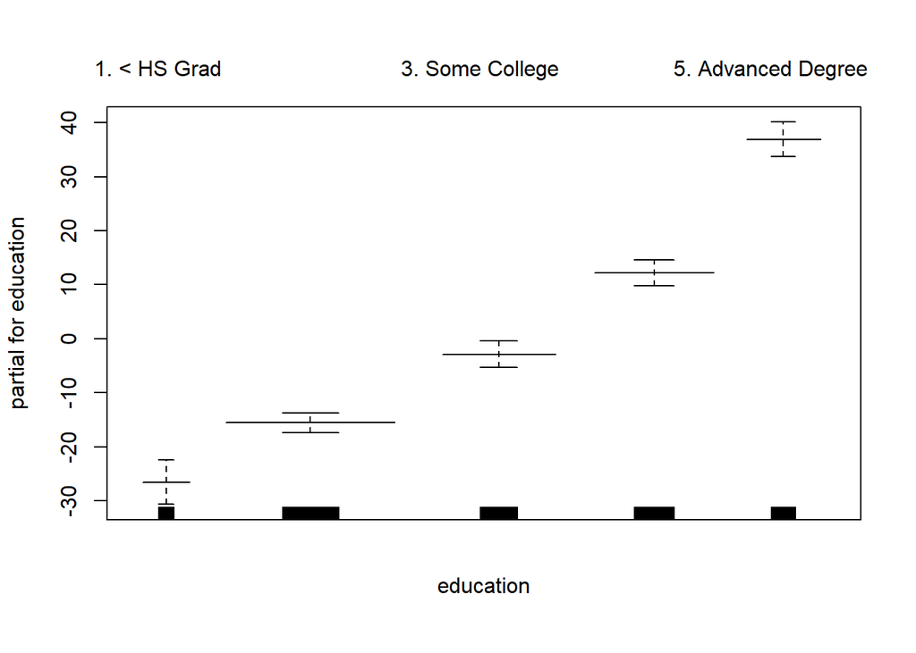

```r
gam.lo <- gam(wage ~ s(year, df = 4) + lo(age, span = 0.7) + education, data = Wage)
plot.Gam(gam.lo, se = TRUE, col = "green")
```

`lo()` fonksiyonu kullanılarak etkileşim terimleri de eklenebilir. Örneğin,

```r
gam.lo.i <- gam(wage ~ lo(year, age, span = 0.5) + education, data = Wage)
```

## 4.1 GAM ile Lojistik Regresyon

GAM fonksiyonu içinde `family=binomial` opsiyonu ile tahmin edilebilir:

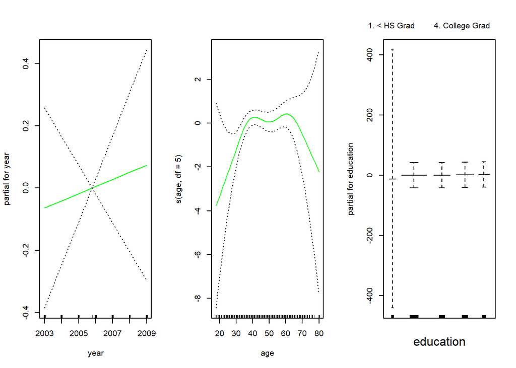

```r
gam.lr <- gam(I(wage > 250) ~ year + s(age, df = 5) + education,
              family = binomial,
              data = Wage)
par(mfrow = c(1, 3))
plot(gam.lr, se = T, col = "green")
```

“<HS” kategorisinde hiç veri olmadığı için oldukça geniş bir güven aralığına sahip:

```r
table(Wage$education, I(Wage$wage > 250))
```

```
##
##                      FALSE TRUE
##   1. < HS Grad         268    0
##   2. HS Grad           966    5
##   3. Some College      643    7
##   4. College Grad      663   22
##   5. Advanced Degree   381   45
```

Bu kategoriyi dışlayarak tekrar tahmin edelim:

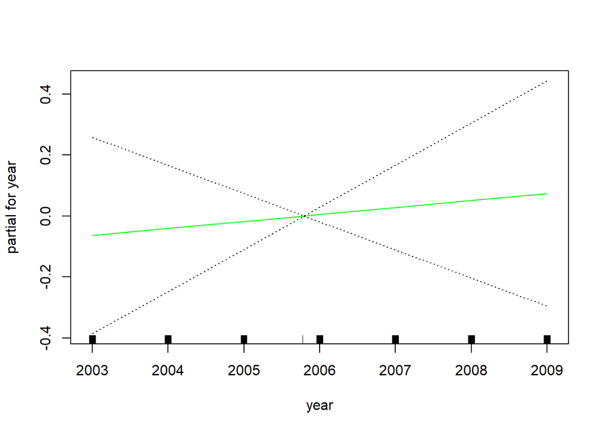

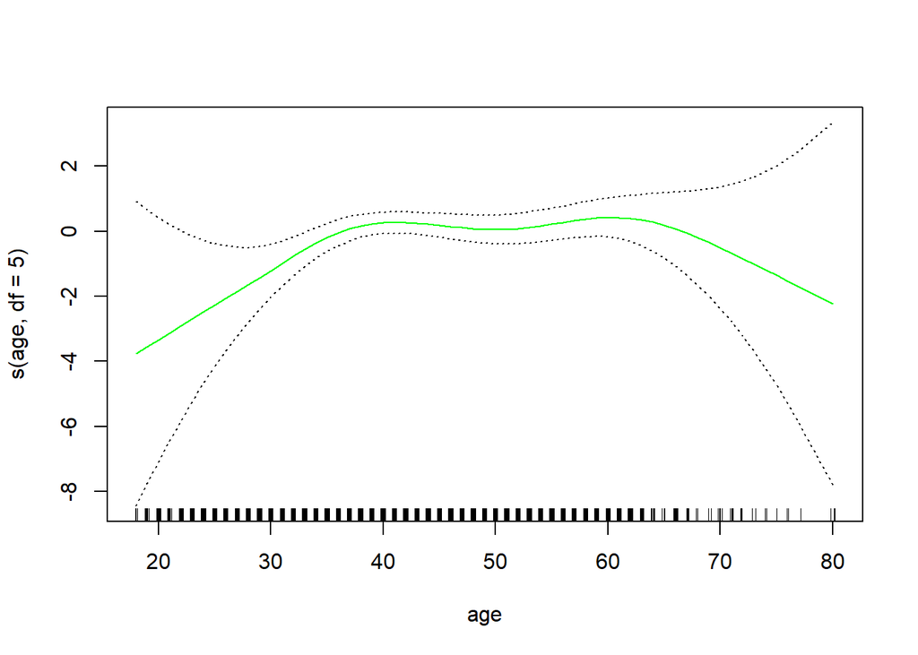

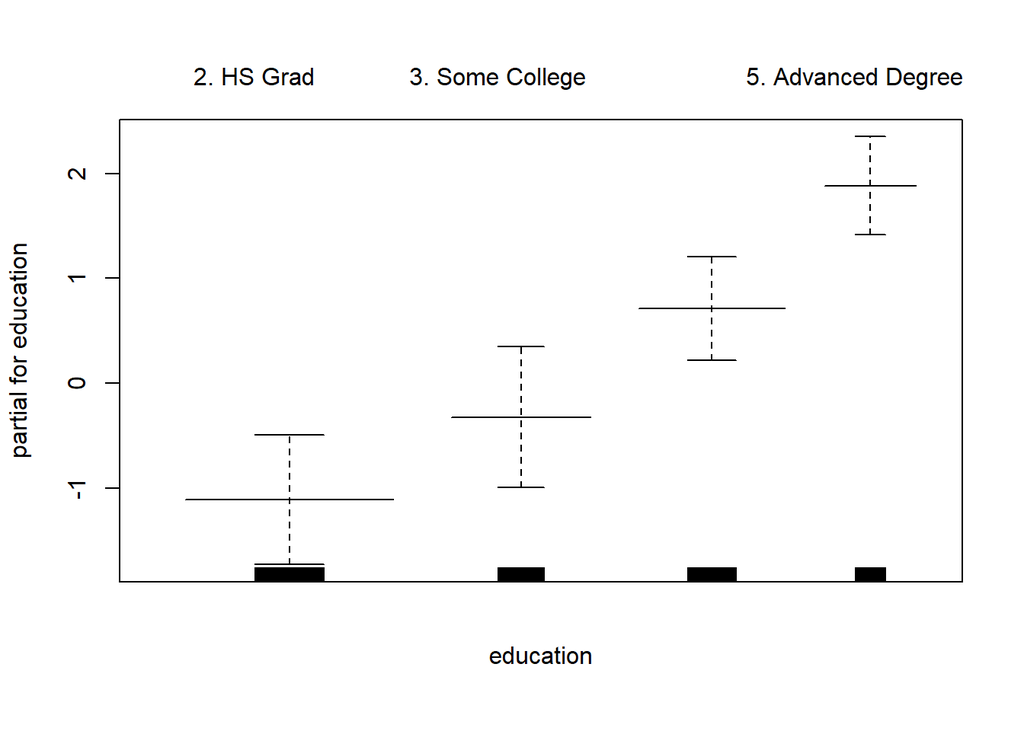

```r
gam.lr.s <- gam(I(wage > 250) ~ year + s(age, df = 5) + education,
                family = binomial,
                data = Wage,
                subset = (education != "1. < HS Grad"))
plot(gam.lr.s, se = T, col = "green")
```

# 5 Yapay Sinir Ağları

Yapay sinir ağları için çeşitli R kütüphaneler bulunmaktadır. Bunlardan biri `{neuralnet}` paketidir (bkz. [neuralnet CRAN page](https://cran.r-project.org/web/packages/neuralnet/index.html)).

```r
library(tidyverse)
library(neuralnet)
```

## 5.1 Simülasyon verileri

```r
# simulate data
set.seed(1)
x1=rnorm(1000)
x2=rnorm(1000)
x3=rnorm(1000)

y=10 + 2*x1 -5*x2 +4*x3 + 3*x1*x2 - 8*x1*x3 + 2*x2*x3 + 5*x1*x2*x3 + rnorm(1000)
df <- tibble(y,x1,x2,x3)
```

```r
# YSA tek katman, aktivasyon=identity
set.seed(12345)
nnet0 <- neuralnet(y ~ x1 + x2 + x3, data=df, act.fct = identity)
summary(nnet0)
```

```
##                     Length Class      Mode
## call                   4   -none-     call
## response            1000   -none-     numeric
## covariate           3000   -none-     numeric
## model.list             2   -none-     list
## err.fct                1   -none-     function
## act.fct                1   -none-     function
## linear.output          1   -none-     logical
## data                   4   data.frame list
## exclude                0   -none-     NULL
## net.result             1   -none-     list
## weights                1   -none-     list
## generalized.weights    1   -none-     list
## startweights           1   -none-     list
## result.matrix          9   -none-     numeric
```

```r
nnet0$result.matrix
```

```
##                                [,1]
## error                  5.813582e+04
## reached.threshold      9.925809e-03
## steps                  7.300000e+01
## Intercept.to.1layhid1 -1.956515e+00
## x1.to.1layhid1        -7.007103e-01
## x2.to.1layhid1         1.372216e+00
## x3.to.1layhid1        -1.183926e+00
## Intercept.to.y         3.147931e+00
## 1layhid1.to.y         -3.293998e+00
```

```r
plot(nnet0)
```

[output not shown]

Lineer regresyon OLS tahmini:

```r
regfit0 <- lm(y ~ x1 + x2 + x3, data=df)
summary(regfit0)
```

```
##
## Call:
## lm(formula = y ~ x1 + x2 + x3, data = df)
##
## Residuals:
##     Min      1Q  Median      3Q     Max
## -82.817  -3.772   0.501   3.891  80.819
##
## Coefficients:
##             Estimate Std. Error t value Pr(>|t|)
## (Intercept)   9.5927     0.3418  28.067  < 2e-16 ***
## x1            2.3081     0.3307   6.979 5.41e-12 ***
## x2           -4.5201     0.3288 -13.748  < 2e-16 ***
## x3            3.8998     0.3320  11.746  < 2e-16 ***
## ---
## Signif. codes:  0 '***' 0.001 '**' 0.01 '*' 0.05 '.' 0.1 ' ' 1
##
## Residual standard error: 10.8 on 996 degrees of freedom
## Multiple R-squared:  0.274,  Adjusted R-squared:  0.2718
## F-statistic: 125.3 on 3 and 996 DF,  p-value: < 2.2e-16
```

Şimdi simülasyon ile oluşturduğumuz veri setinden hareketle train-test ayırımı yapalım. Bundan önce, değişkenleri 0-1 aralığına olacak şekilde standardize edelim:

```r
scale1 <- function(x){
  (x - min(x)) / (max(x) - min(x))
}
dfs <- df %>% mutate_all(scale1)
```

```r
# %75 train %25 test
set.seed(555)
train_id <- sample(1000, 750)
dfs_train <- dfs[train_id, ]
dfs_test <- dfs[-train_id, ]
```

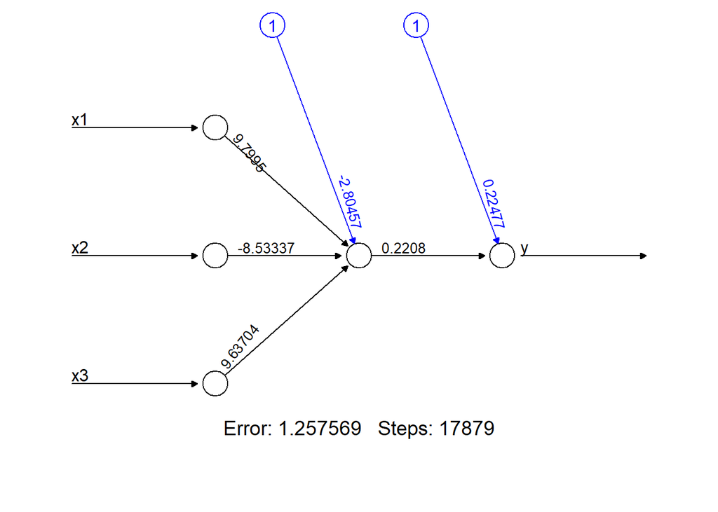

```r
# 1 hücreli tek katman, default act.fct = "logistic" (i.e., sigmoid)
nnet1 <- neuralnet(y ~ x1 + x2 + x3, data=dfs_train)
plot(nnet1, rep = "best")
```

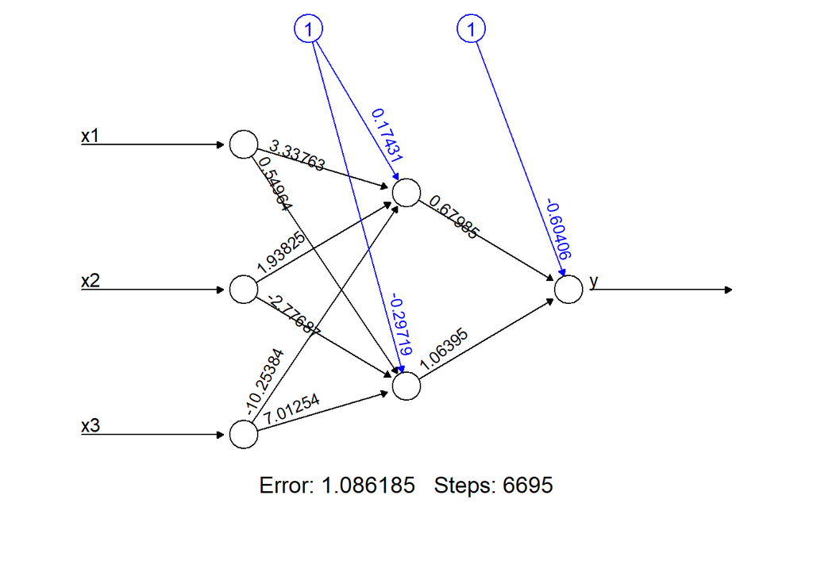

```r
# 2 hücreli tek katman
nnet2 <- neuralnet(y ~ x1 + x2 + x3, data=dfs_train, hidden=2)
plot(nnet2, rep = "best")
```

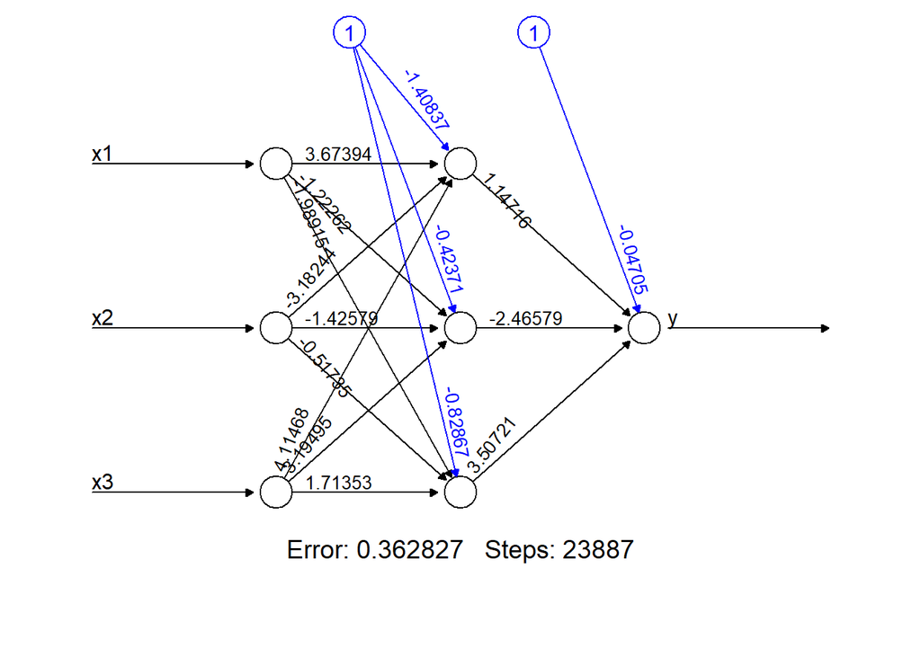

```r
# 3 hücreli tek katman
nnet3 <- neuralnet(y ~ x1 + x2 + x3, data=dfs_train, hidden=3)
plot(nnet3, rep = "best")
```

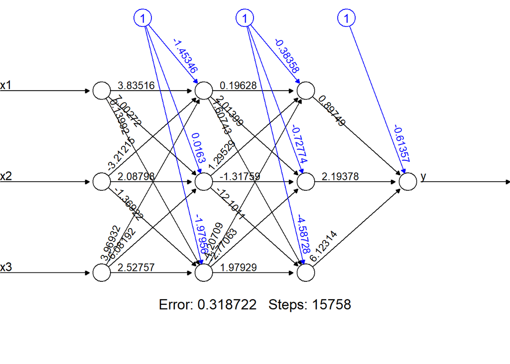

```r
# 3 hücreli 2 katman
# relu <- function(x) {max(0,x)}
nnet4 <- neuralnet(y ~ x1 + x2 + x3, data=dfs_train, hidden=c(3,3))
plot(nnet4, rep = "best")
```

Test veri setinde kestirim hatası:

```r
pred_nnet4 <- predict(nnet4, newdata = dfs_test)
mse_nnet4 <- mean((dfs_test$y - pred_nnet4)^2)
mse_nnet4
```

```
## [1] 0.001518029
```

Bunu lineer regresyon ile karşılaştıralım:

```r
linreg <- lm(y ~ x1 + x2 + x3, data = dfs_train)
pred_linreg <- predict(linreg, newdata = dfs_test)
mse_linreg <- mean((dfs_test$y - pred_linreg)^2)
mse_linreg
```

```
## [1] 0.006065131
```

Bu YSA modeline göre daha büyüktür. Lineer modele etkileşim terimleri ekleyelim:

```r
linreg2 <- lm(y ~ x1*x2*x3, data = dfs_train)
summary(linreg2)
```

```
##
## Call:
## lm(formula = y ~ x1 * x2 * x3, data = dfs_train)
##
## Residuals:
##       Min        1Q    Median        3Q       Max
## -0.020642 -0.004792 -0.000036  0.004676  0.020356
##
## Coefficients:
##             Estimate Std. Error t value Pr(>|t|)
## (Intercept) -0.97289    0.00915 -106.33   <2e-16 ***
## x1           3.50947    0.02059  170.41   <2e-16 ***
## x2           1.45794    0.01867   78.09   <2e-16 ***
## x3           2.97470    0.01641  181.30   <2e-16 ***
## x1:x2       -4.54202    0.04155 -109.31   <2e-16 ***
## x1:x3       -6.97838    0.03611 -193.27   <2e-16 ***
## x2:x3       -3.79397    0.03330 -113.93   <2e-16 ***
## x1:x2:x3     9.90535    0.07262  136.40   <2e-16 ***
## ---
## Signif. codes:  0 '***' 0.001 '**' 0.01 '*' 0.05 '.' 0.1 ' ' 1
##
## Residual standard error: 0.006887 on 742 degrees of freedom
## Multiple R-squared:  0.9927, Adjusted R-squared:  0.9926
## F-statistic: 1.434e+04 on 7 and 742 DF,  p-value: < 2.2e-16
```

```r
options(scipen = 999) # bilimsel notasyonu kapat
pred_linreg2 <- predict(linreg2, newdata = dfs_test)
mse_linreg2 <- mean((dfs_test$y - pred_linreg2)^2)
mse_linreg2
```

```
## [1] 0.00004746836
```

Bu çok daha başarılı bir kestirim performansına sahiptir. Ancak burada doğru modeli bildiğimiz için doğrudan tahmin ettik. Çok sayıda kestirim değişkenlerinin olduğu durumda hangi etkileşimleri ekleyeceğimizi genellikle bilemeyiz.

Kestirimleri görselleştirebiliriz:

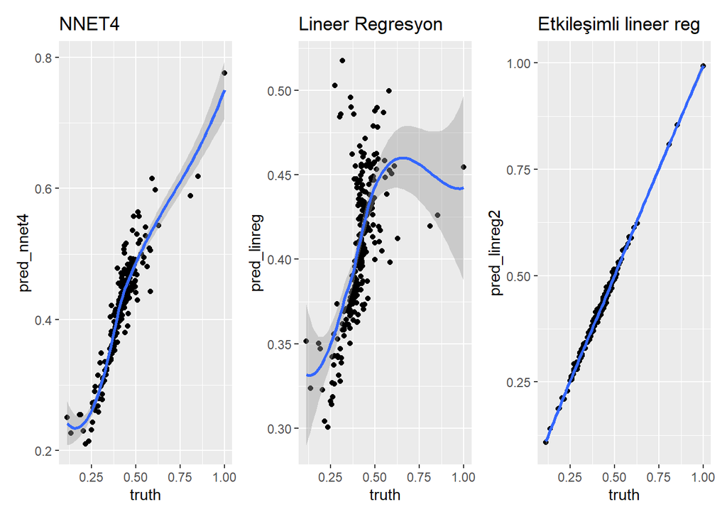

```r
data_pred <- tibble(pred_nnet4, pred_linreg, pred_linreg2, truth = dfs_test$y)
p1 <- ggplot(data_pred, aes(truth, pred_nnet4)) +
  geom_point() +
  geom_smooth() +
  ggtitle("NNET4")
p2 <- ggplot(data_pred, aes(truth, pred_linreg)) +
  geom_point() +
  geom_smooth() +
  ggtitle("Lineer Regresyon")
p3 <- ggplot(data_pred, aes(truth, pred_linreg2)) +
  geom_point() +
  geom_smooth() +
  ggtitle("Etkileşimli lineer reg")
# plot
library(patchwork)
p1 | p2 | p3
```

## 5.2 Örnek: Boston housing data

```r
library(MASS)
library(neuralnet)
data("Boston")
```

```r
# scale variables, except chas and medv
# boston <- as_tibble(Boston) %>%
#  mutate(across(.cols=-c("chas","medv"), scale1))
boston <- as_tibble(Boston) %>%
  mutate(across(.cols=-c("chas"), scale1))
# scale1 fonksiyonu yukarıda tanımlanmıştı
```

```r
# train-test split
library(rsample)
set.seed(10) # for replication
boston_split <- initial_split(boston,
                           prop = 0.75,
                           strata = medv)
```

```r
# train-test verileri
boston_train <- boston_split %>% training()
boston_test <- boston_split %>% testing()
```

```r
# iki saklı katman, herbirinde 5 nöron
set.seed(1010)
nn1 <- neuralnet(medv ~ crim + zn + indus + chas + nox + rm + age + dis + rad + tax +
                   ptratio + black + lstat,
                 data = boston_train,
                 hidden = c(5,5))
```

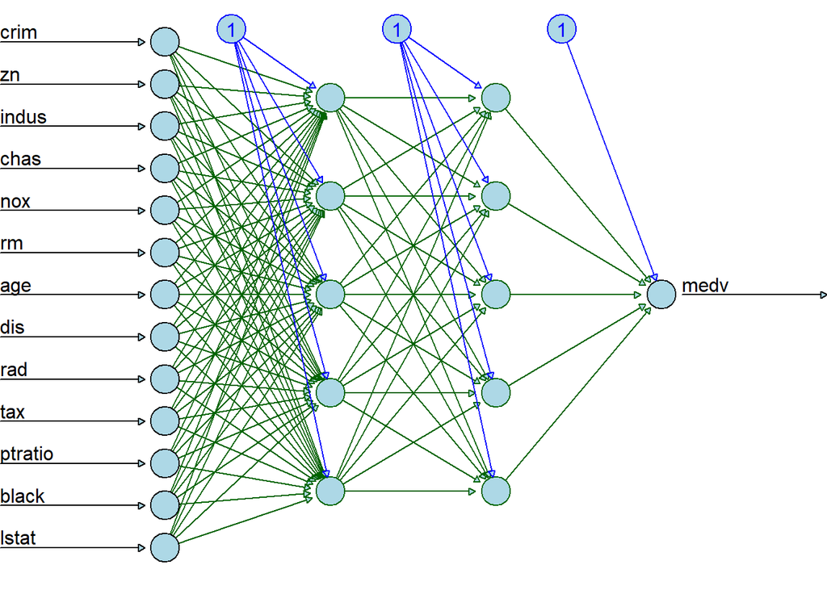

```r
# YSA'nın yapısı
plot(nn1, col.hidden = 'darkgreen',
     col.hidden.synapse = 'darkgreen',
     show.weights = F,
     information = F,
     fill = 'lightblue',
     rep = "best"   # to render graph in html output
     )
```

```r
# kestirimler
pred_nn1 <- predict(nn1, newdata = boston_test)

# scale1'i tersine çevir
pred_nn1_converted <- (max(pred_nn1)-min(pred_nn1))*pred_nn1 + min(pred_nn1)
test_medv <- (max(boston_test$medv)-min(boston_test$medv))*boston_test$medv + min(boston_test$medv)
# tibble oluştur
result_data <- tibble(test_medv, pred_nn1_converted)
head(result_data)
```

```
## # A tibble: 6 x 2
##   test_medv pred_nn1_converted[,1]
##       <dbl>                  <dbl>
## 1     0.369                  0.444
## 2     0.398                  0.417
## 3     0.256                  0.336
## 4     0.222                  0.460
## 5     0.309                  0.401
## 6     0.293                  0.367
```

```r
# MSE hesapla
mse_boston_nn1 <- mean((pred_nn1_converted - test_medv)^2)
mse_boston_nn1
```

```
## [1] 0.01119983
```

```r
# tüm değişkenlerle lineer regresyon
reg1 <- lm(medv ~ crim + zn + indus + chas + nox + rm + age + dis + rad + tax +
                   ptratio + black + lstat, data = boston_train)
pred_reg1 <- predict(reg1, newdata = boston_test)
pred_reg1_converted <- (max(pred_reg1)-min(pred_reg1))*pred_reg1 + min(pred_reg1)
result_data$pred_reg1_converted <- pred_reg1_converted
head(result_data)
```

```
## # A tibble: 6 x 3
##   test_medv pred_nn1_converted[,1] pred_reg1_converted
##       <dbl>                  <dbl>               <dbl>
## 1     0.369                  0.444              0.263
## 2     0.398                  0.417              0.212
## 3     0.256                  0.336             -0.0744
## 4     0.222                  0.460              0.117
## 5     0.309                  0.401              0.180
## 6     0.293                  0.367              0.119
```

```r
# lineer regresyon MSE değeri
mse_boston_reg1 <- mean((pred_reg1_converted - test_medv)^2)
mse_boston_reg1
```

```
## [1] 0.04876404
```

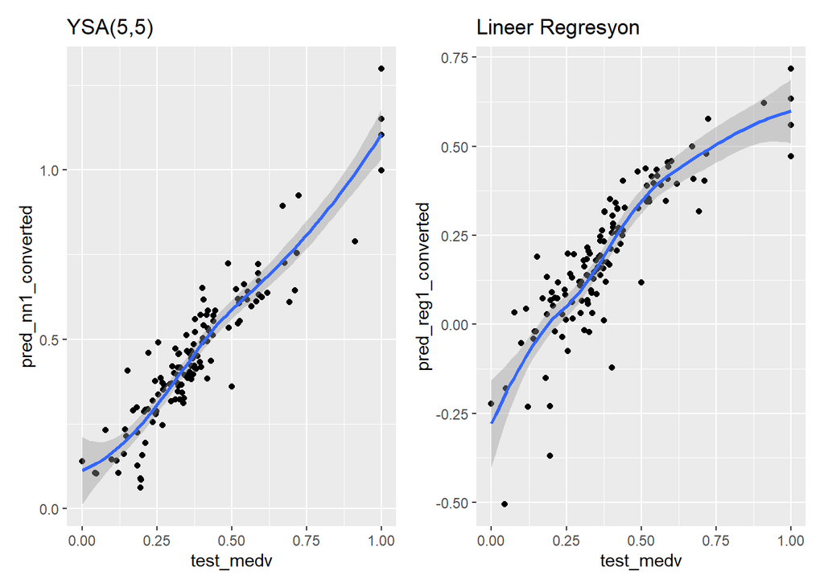

```r
# Kestirim karşılaştırması
p1 <- ggplot(result_data, aes(test_medv, pred_nn1_converted)) +
  geom_point() +
  geom_smooth() +
  ggtitle("YSA(5,5)")
p2 <- ggplot(result_data, aes(test_medv, pred_reg1_converted)) +
  geom_point() +
  geom_smooth() +
  ggtitle("Lineer Regresyon")
# plot
library(patchwork)
p1 | p2
```